# Aplicacion de vacunas COVID19 en Argentina - NOMIVAC: 2020-2023

Lautaro Felipe Skubaletzky

# Introducción

## ¿Qué datos son?

- Los datos contienen informacion de las aplicaciones de vacunas contra el COVID19.
- A nivel individual, cada fila corresponde a una nueva aplicacion de vacuna.
- Para cada aplicacion disponemos de datos:
  - Desnominalizados del **SUJETO QUIEN** es receptor. *(id_persona_dw)*.
  - Categoricas como **DICOTOMICAS** del sexo y **RANGOS** por grupo etario. *(sexo y grupo_etario)*.
  - … un score de prioridad **ORDINAL** segun edad y factores de riesgo. *(condicion_aplicacion)*.
  - Informacion temporal del **CUANDO** se aplica. **YYYY-MM-DD.** *(fecha_aplicacion)*.
  - Informacion de departamento y jurisdiccion **DONDE** residence. **GEOREF.** *(jurisdiccion_residencia y depto_residencia)*.
  - Informacion de departamente y jurisdiccion **DONDE** se aplica. **GEOREF.** *(jurisdiccion_aplica y depto_aplica)*
  - … **QUÉ** vacuna recibe. *(vacuna)*
  - … **QUÉ** lote descarga esa dosis. *(lote_vacuna)*
  - … **CANTIDAD** de dosis recibidas. *(orden_dosis)*
  - … **ESTADO DE AVANCE** con el esquema. *(nombre_dosis_generica)*
  - … adicionalmente a estos datos existen otras variables numericas que acompañan a las últimas manteniendo correspondencia entre **Códigos Ids** y **valores-definición.**

Para enternder un poco mas sobre los esquemas de vacunación y refuerzos para las diferentes poblaciones, visitar la pagina [sobre la vacunación contra el COVID19.](https://www.argentina.gob.ar/coronavirus/vacuna)

Existe un dataset adicional en relacion a éste que registra los precios en dólares pagados por cada dosis por parte del Ministerio de Salud de la Nación. [**Link**](http://datos.salud.gob.ar/dataset/precio-unitario-de-vacunas-covid-19-adquiridas-por-el-ministerio-de-salud-de-la-nacion)

## ¿De dónde provienen? ¿Quién los tomó?

Los datos fueron obtenidos del sitio de datos abiertos de la pagina de la nacion [“datos abiertos argentina.”](https://datos.gob.ar/dataset/salud-vacunas-contra-covid-19-dosis-aplicadas-republica-argentina---registro-desagregado)

Los datos son propiedad del **Ministerio de Salud de la Nación, Dirección de Control de Enfermedades Inmunoprevenibles (DiCEI)** quien mantiene actualizado y online el dataset.

Por otro lado, el registro está a cargo del **Programa Nacional de Control de Enfermedades Inmunoprevenibles (ProNaCEI)**, creado por [Resolución Ministerial 776/2010](https://bancos.salud.gob.ar/sites/default/files/2018-10/0000000494cnt-2013-10_resolucion-ministerial-259.pdf), cuyo propósito es disminuir la mortalidad a causa de dichas enfermedades, mediante la vacunación sostenida de los niños y adultos según vacuna y población objeto definida.

## ¿En qué período se tomaron?

Los datos corresponden al periodo que comprende la pandemia del COVID19.

El registro mas antiguo es del *29/12/2020* que podría corresponder a la aplicación de los primeros lotes de vacunas nacionalizadas o primeros vacunados registrados en el [NOMIVAC - Registro Federal de Vacunación Nominalizado](https://sisa.msal.gov.ar/sisadoc/docs/050203/nomivac_home.jsp). Sin perjuicio de ello, el registro se creó el *23/03/2021* dando apertura a su publicacion en “datos abiertos” a partir de esa fecha.

Según la [pagina web](https://datos.gob.ar/dataset/salud-vacunas-contra-covid-19-dosis-aplicadas-republica-argentina---registro-desagregado/archivo/salud_e4515c25-e1fd-4f02-b1c1-5453c36eada6) en donde se encuentra disponible la base de datos, la frecuencia de actualizacion es a diario.

El registro mas reciente del que se dispone es del *29/04/2023*, fecha en la que se realizó mi descarga y que luego se filtró la base en cantidad de observaciones para poder importarla de manera completa.

# Exploración de los datos

Los datos ingresados son tan solo una parte de la base, puesto que los ingredientes no entran todos juntos en la cocina… La base completa cuenta con 18 variables entre numeros enteros, fechas, palabras, codigos_id, etc. y unas 115 millones de filas. Intenté durante mucho, mucho^2, mucho^mucho, cargar esos datos a RStudio pero siempre fallo la carga vía read_csv, entonces en “/scripts/0_importa-datos.R”, limite la cantidad de filas a leer, para poder avanzar con el TP1.

```
##
## > library(readr)
##
## > file_path <<- "datos/datos_nomivac_covid19.csv"
##
## > data <- read_csv(file_path, n_max = 1.15e+08)
```

## Exploracion de dominio (valores unicos en cada variable)

A continuacion exploro cuales son los posibles valores que adoptan las variables, es decir su dominio, en terminos del “estado de la variable”.

```r
levels(factor(data$sexo))
levels(factor(data$grupo_etario))
#levels(factor(data$jurisdiccion_residencia))
#levels(factor(data$depto_residencia))
#levels(factor(data$jurisdiccion_aplicacion))
#levels(factor(data$depto_aplicacion))
#levels(factor(data$fecha_aplicacion))
levels(factor(data$vacuna))
levels(factor(data$nombre_dosis_generica))
levels(factor(data$condicion_aplicacion))
#levels(factor(data$lote_vacuna))
levels(factor(data$orden_dosis))
```

[output not shown]

```r
data <- data %>%
  rename(id_persona = id_persona_dw)
```

## Correccion de datos (normalizacion y homogeneizacion)

**grupo_etario (normalización):** Se hallaron diferentes formas de ingresar datos sobre las edades y resulta procedente tenerlos mejor organizados bajo un esquema alfabetico del tipo 0-9/A-Z. A continuacion se modifican datos de grupo_etario según conveniencia.

```r
data <- data %>%
  mutate(grupo_etario = case_when(
    grupo_etario == "<12"   ~ "000-012",
    grupo_etario == "12-17" ~ "012-017",
    grupo_etario == "18-29" ~ "018-029",
    grupo_etario == "30-39" ~ "030-039",
    grupo_etario == "40-49" ~ "040-049",
    grupo_etario == "50-59" ~ "050-059",
    grupo_etario == "60-69" ~ "060-069",
    grupo_etario == "70-79" ~ "070-079",
    grupo_etario == "80-89" ~ "080-089",
    grupo_etario == "90-99" ~ "090-099",
    grupo_etario == ">=100" ~ "100-199",
    TRUE ~ grupo_etario
  ))
```

Se han normalizado los strings para mejor ordenamiento del grupo_etario.

**condicion_aplicacion (edición):** Se consideran incorrectos algunos valores del dominio de la variable condicion_aplicacion ya que repite informacion reservada para informarse a traves de la variable de grupo_etario. Esta situacion tambien genera una desagregacion importante en subgrupos de personas con y sin factores de riesgo, desagrupados por edad. Se remueve la informacion de grupo_etario de la variable condicion_aplicacion para que se agrupen un poco más en funcion del concepto.

```r
levels(factor(data$condicion_aplicacion))
```

```
##  [1] "12 a 17 años CON Factores de Riesgo" "12 a 17 años SIN Factores de Riesgo"
##  [3] "18 a 39 años SIN Factores de Riesgo" "18 a 59 años CON Factores de Riesgo"
##  [5] "3 a 11 años CON Factores de Riesgo"  "3 a 11 años SIN Factores de Riesgo"
##  [7] "40 a 49 años SIN Factores de Riesgo" "50 a 59 años SIN Factores de Riesgo"
##  [9] "60 o más años"                       "CON Factores de Riesgo"
## [11] "Embarazo"                            "Estratégico"
## [13] "Otros"                               "Salud"
## [15] "SIN Factores de Riesgo"              "Viaje"
```

```r
data <- data %>%
  mutate(condicion_aplicacion = ifelse(condicion_aplicacion == "60 o más años", "Adulto mayor", condicion_aplicacion))

data <- data %>%
  mutate(condicion_aplicacion = ifelse(str_detect(condicion_aplicacion, "años"),
                            str_extract(condicion_aplicacion, "(?<=años\\s).*"),
                            condicion_aplicacion))

data <- data %>%
  mutate(condicion_aplicacion = case_when(
    condicion_aplicacion == "Adulto mayor"           ~ "Adulto mayor",
    condicion_aplicacion == "Estratégico"            ~ "Estratégico",
    condicion_aplicacion == "Salud"                  ~ "Salud",
    condicion_aplicacion == "CON Factores de Riesgo" ~ "Factores Riesgo ON",
    condicion_aplicacion == "Embarazo"               ~ "Embarazo",
    condicion_aplicacion == "Viaje"                  ~ "Viaje",
    condicion_aplicacion == "Otros"                  ~ "Otros",
    condicion_aplicacion == "SIN Factores de Riesgo" ~ "Factores Riesgo OFF",
    TRUE ~ condicion_aplicacion
  ))

levels(factor(data$condicion_aplicacion))
```

```
## [1] "Adulto mayor"        "Embarazo"            "Estratégico"
## [4] "Factores Riesgo OFF" "Factores Riesgo ON"  "Otros"
## [7] "Salud"               "Viaje"
```

Se han editado las categorías para simplificar su analisis.

**sexo (agrupacion):** sexo tiene dom{“F”,“M”,“S.I.”,“X”} donde X y S.I. (se asume sin especificar) resultan indistinto para analizar por ende restringimos el dominio => dom{“F”,“M”,“S.I.”}.

```r
levels(factor(data$sexo))
```

```
## [1] "F"    "M"    "S.I." "X"
```

```r
data <- data %>%
  mutate(sexo = ifelse(sexo=="X", "S.I.", sexo))

levels(factor(data$sexo))
```

```
## [1] "F"    "M"    "S.I."
```

Se agrupo sexo = “X” con sexo = “S.I.”.

## Obtengo algunos df para explorar cantidades y participacion variables de interes y de poblacion objetivo.

Cuantos por genero/edad/condicion tomados por cantidad de dosis tuvieron 1 / 2 / 3… dosis.

```r
data %>%
  group_by(sexo) %>%
  summarise(pob = length(sexo)) %>%
  mutate(participacion_relativa = pob / sum(pob) * 100) %>%
  arrange(desc(sexo))
```

```
## # A tibble: 3 × 3
##   sexo       pob participacion_relativa
##   <chr>    <int>                  <dbl>
## 1 S.I.    146221                  0.219
## 2 M     31348784                 46.9
## 3 F     35385176                 52.9
```

En la base hay mas mujeres que recibieron vacunas que hombres.

```r
data %>%
  group_by(grupo_etario) %>%
  summarise(pob = length(grupo_etario)) %>% ## existe repeticion de personas.
  mutate(participacion_relativa = pob / sum(pob) * 100) %>%
  arrange(desc(grupo_etario))
```

```
## # A tibble: 12 × 3
##    grupo_etario      pob participacion_relativa
##    <chr>           <int>                  <dbl>
##  1 S.I.               27              0.0000404
##  2 100-199          8533              0.0128
##  3 090-099        338857              0.507
##  4 080-089       1980111              2.96
##  5 070-079       5190003              7.76
##  6 060-069       7630468             11.4
##  7 050-059       8467880             12.7
##  8 040-049       9983568             14.9
##  9 030-039       9900138             14.8
## 10 018-029      11223629             16.8
## 11 012-017       5365994              8.02
## 12 000-012       6790973             10.2
```

Se observa que quienes mas vacunaciones tienen son el grupo de 18 a 29 años. Esto puede deberse al recorte realizado, o bien que estas personas estan en trabajos estrategicos.

```r
data %>%
  group_by(condicion_aplicacion) %>%
  summarise(pob = length(id_persona)) %>% ## existe repeticion de personas.
  mutate(participacion_relativa = pob / sum(pob) * 100) %>%
  arrange(desc(pob))
```

```
## # A tibble: 8 × 3
##   condicion_aplicacion      pob participacion_relativa
##   <chr>                   <int>                  <dbl>
## 1 Factores Riesgo OFF  37917810                56.7
## 2 Factores Riesgo ON   13258510                19.8
## 3 Adulto mayor          8674513                13.0
## 4 Estratégico           3750103                 5.61
## 5 Salud                 2622012                 3.92
## 6 Otros                  600461                 0.898
## 7 Embarazo                32014                 0.0479
## 8 Viaje                   24758                 0.0370
```

Se vacunaron mas personas **sin** factores de riesgo que **con** factores de riesgo, lo que en un primer momento puede parecer contraintuitivo. Se produce una confusion por la creencia en que personas con factores de riesgo serían mas prevalentes en la base, pero no es así, ya que no es la categoría de mas personas en la base. Por otro lado, lo que sí es correcto esperarse, es ver la poblacion con factores de riesgo, siendo vacunada con prioridad en las primeras rondas y con mayor cantidad de dosis que otras poblaciones.

**Devenido del analisis anterior:** se aprecia un error en la concepcion de estos datos. La base no fué filtrada por id_personadw por lo tanto existen multiples registros de aplicacion de vacunas para cada persona, en diferentes momentos (se cree). Si hubieramos importado la base completa quedaría en evidencia que existen varios registros (filas) por persona, una fila por cada aplicacion. Ya que importamos solo un recorte de los datos para no colapsar la memoria del ordenador no quedo tan en evidencia que la cantidad de registros (aprox.115millones) no cuadra ni de cerca con la cantidad de habitantes (aprox.45millones).

**Como utilizar la base de forma correcta:** para cada id_persona deberia analizarse en estas descriptivas solamente el ultimo registro alcanzado y aclarar bien definidamente que se considera un intervalo temporal de los registros totales que comienza en t(0) y termina en t(T). Es decir, es necesario filtrar filas para que solo me queden los datos de la ultima “foto” del estado de situacion hasta el momento t(T) de cada persona. “no se como operar eso”.

### Minimo, promedio y maximo de dosis aplicadas a cada poblacion objetivo:

```r
data %>%
  group_by(sexo) %>%
  summarise(min_dosis = min(orden_dosis),
            mean_dosis = mean(orden_dosis),
            max_dosis = max(orden_dosis),
            n_grupo = length(orden_dosis)) %>%
mutate(n_relativo = n_grupo / sum(n_grupo) * 100 )  %>%
arrange(desc(sexo))
```

```
## # A tibble: 3 × 6
##   sexo  min_dosis mean_dosis max_dosis  n_grupo n_relativo
##   <chr>     <dbl>      <dbl>     <dbl>    <int>      <dbl>
## 1 S.I.          1       1.98         7   146221      0.219
## 2 M             1       2.37         7 31348784     46.9
## 3 F             1       2.43         7 35385176     52.9
```

Las mujeres en promedio se aplicaron mas vacunas que los hombres y adicionalmente forman un grupo mas numeroso. Mediante otros analisis puede comprobarse si estas medias realmente difieren estadisticamente [link.](https://openstax.org/books/introducci%C3%B3n-estad%C3%ADstica-empresarial/pages/10-1-comparacion-de-las-medias-de-dos-poblaciones-independientes)

```r
data %>%
  group_by(grupo_etario) %>%
  summarise(min_dosis = min(orden_dosis),
            mean_dosis = mean(orden_dosis),
            max_dosis = max(orden_dosis),
            n_grupo = length(grupo_etario)) %>%
mutate(n_relativo = n_grupo / sum(n_grupo) * 100 )  %>%
arrange(desc(mean_dosis))
```

```
## # A tibble: 12 × 6
##    grupo_etario min_dosis mean_dosis max_dosis  n_grupo n_relativo
##    <chr>            <dbl>      <dbl>     <dbl>    <int>      <dbl>
##  1 060-069              1       2.74         7  7630468 11.4
##  2 070-079              1       2.74         7  5190003  7.76
##  3 050-059              1       2.70         7  8467880 12.7
##  4 080-089              1       2.68         7  1980111  2.96
##  5 090-099              1       2.66         7   338857  0.507
##  6 100-199              1       2.57         7     8533  0.0128
##  7 040-049              1       2.50         7  9983568 14.9
##  8 030-039              1       2.36         7  9900138 14.8
##  9 018-029              1       2.22         7 11223629 16.8
## 10 012-017              1       2.11         7  5365994  8.02
## 11 S.I.                 1       1.89         4       27  0.0000404
## 12 000-012              1       1.75         7  6790973 10.2
```

Se puede apreciar que casi todos los grupos etarios tienen un promedio de aplicaciones similar, y los valores extremos de minimos y maximos practicamente iguales.

```r
data %>%
  group_by(condicion_aplicacion) %>%
  summarise(min_dosis = min(orden_dosis),
            mean_dosis = mean(orden_dosis),
            max_dosis = max(orden_dosis),
            n_grupo = length(condicion_aplicacion)) %>%
  mutate(n_relativo = n_grupo / sum(n_grupo) * 100 )  %>%
  arrange(desc(mean_dosis))
```

```
## # A tibble: 8 × 6
##   condicion_aplicacion min_dosis mean_dosis max_dosis  n_grupo n_relativo
##   <chr>                    <dbl>      <dbl>     <dbl>    <int>      <dbl>
## 1 Otros                        1       2.98         7   600461     0.898
## 2 Factores Riesgo ON           1       2.84         7 13258510    19.8
## 3 Embarazo                     1       2.74         6    32014     0.0479
## 4 Adulto mayor                 1       2.53         7  8674513    13.0
## 5 Factores Riesgo OFF          1       2.29         7 37917810    56.7
## 6 Salud                        1       2.10         6  2622012     3.92
## 7 Estratégico                  1       1.83         6  3750103     5.61
## 8 Viaje                        1       1.14         5    24758     0.0370
```

## Analisis para el grupo de factores de riesgo, como se compone en genero y edad.

```r
data %>%
  filter(condicion_aplicacion == "Factores Riesgo ON") %>%
  group_by(grupo_etario) %>%
  summarise(orden_dosis_mean = mean(orden_dosis),
            pob = length(orden_dosis)) %>%
  mutate() %>%
  arrange(desc(pob))
```

```
## # A tibble: 11 × 3
##    grupo_etario orden_dosis_mean     pob
##    <chr>                   <dbl>   <int>
##  1 050-059                  2.78 3338862
##  2 040-049                  2.89 2965177
##  3 030-039                  2.92 2153464
##  4 018-029                  2.93 2041361
##  5 012-017                  2.70  949316
##  6 060-069                  2.97  681921
##  7 000-012                  2.07  476213
##  8 070-079                  2.92  426642
##  9 080-089                  2.91  183560
## 10 090-099                  2.90   40655
## 11 100-199                  2.85    1339
```

## Creo nuevas variables que me sirvan para operar con la fecha

```r
data %>%
  group_by(id_persona) %>%
  filter(fecha_aplicacion == max(fecha_aplicacion)) %>%
  group_by(condicion_aplicacion) %>%
  summarise(dosis_media = mean(orden_dosis),
            pob = length(orden_dosis)) %>%
  mutate(pob_rel = pob / sum(pob) * 100 ) %>%
  arrange(dosis_media, pob)
```

```
## # A tibble: 8 × 4
##   condicion_aplicacion dosis_media      pob pob_rel
##   <chr>                      <dbl>    <int>   <dbl>
## 1 Viaje                       1.16    18470  0.0532
## 2 Estratégico                 2.40  1267208  3.65
## 3 Factores Riesgo OFF         2.54 22524662 64.9
## 4 Salud                       2.75   902088  2.60
## 5 Embarazo                    2.79    25441  0.0733
## 6 Otros                       3.15   423820  1.22
## 7 Adulto mayor                3.16  2255638  6.50
## 8 Factores Riesgo ON          3.24  7294358 21.0
```

Siguiendo con el analisis temporal de los datos quisiera saber que cantidad de dosis se aplicaron cada día.

```r
data %>%
  group_by(fecha_aplicacion) %>%
  summarise(aplicacion_diaria = length(id_persona)) %>%
  arrange(fecha_aplicacion)
```

```
## # A tibble: 852 × 2
##    fecha_aplicacion aplicacion_diaria
##    <date>                       <int>
##  1 2020-12-29                    7617
##  2 2020-12-30                    7523
##  3 2020-12-31                    1098
##  4 2021-01-01                      58
##  5 2021-01-02                    1274
##  6 2021-01-03                     164
##  7 2021-01-04                    3972
##  8 2021-01-05                    4105
##  9 2021-01-06                    3748
## 10 2021-01-07                    6863
## # ℹ 842 more rows
```

```r
## este cuadro tiene potencial para verse bien en grafico.
```

Distribucion de vacunas por provincia de aplicacion

```r
data %>%
  group_by(jurisdiccion_aplicacion) %>%
  summarise(pob = length(jurisdiccion_aplicacion)) %>%
  mutate(pob_rel = pob / sum(pob) * 100 ) %>%
  arrange(desc(pob))
```

```
## # A tibble: 24 × 3
##    jurisdiccion_aplicacion      pob pob_rel
##    <chr>                      <int>   <dbl>
##  1 Buenos Aires            25589888   38.3
##  2 CABA                     6548432    9.79
##  3 Santa Fe                 5714004    8.54
##  4 Córdoba                  5181103    7.75
##  5 Mendoza                  2794735    4.18
##  6 Tucumán                  2048531    3.06
##  7 Entre Ríos               1873655    2.80
##  8 Corrientes               1853063    2.77
##  9 Salta                    1803693    2.70
## 10 Santiago del Estero      1452619    2.17
## # ℹ 14 more rows
```

Era de esperar Buenos Aires a la cabeza.

## Quisiera empezar con algunos graficos

por ejemplo:

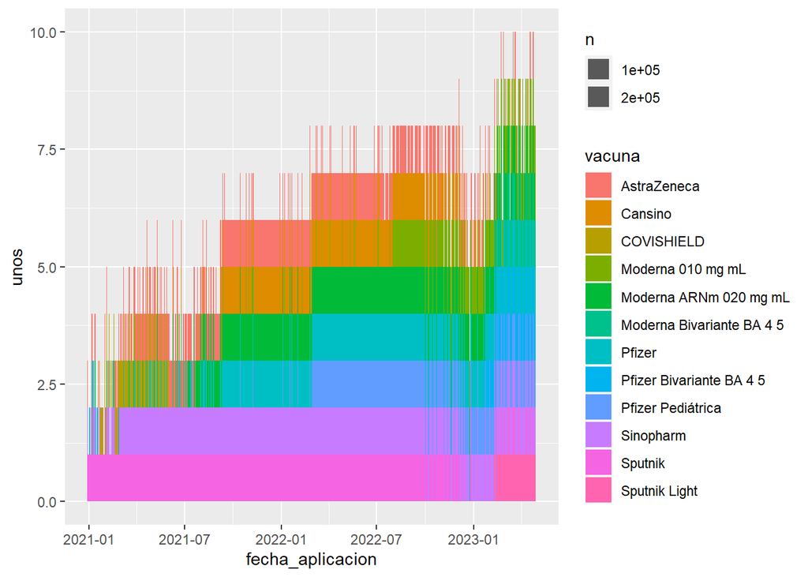

```r
data <- mutate(data, unos = 1)

ggplot(data, mapping = aes(x = fecha_aplicacion, fill = vacuna)) +
         geom_bar(stat = "sum", mapping = aes(y = unos))
```

[monitor de vacunas covid](https://www.argentina.gob.ar/coronavirus/vacuna/aplicadas) ….

[figure not shown]

## Hipótesis

Debido a la disponibilidad gradual de dosis de vacunas al comienzo de la pandemia resulta necesario establecer una priorización y ordenamiento de la poblacion objetivo a inmunizar en las primeras rondas con la finalidad de salvaguardar aquellos mas susceptibles, vulnerables y expuestos. Para maximizar el cuidado de la gente se cree que mayores de edad, personas con comorbilidades y personal estrategico fueron los priorizados del sistema.

1. Por esta razón se indagará en las etapas tempranas de vacunacion la incidencia de la poblacion objetivo sobre el total y comparar esos valores con los registrados al finalizar la emergencia mundial cuando la vacuna alcanzo la suficiencia en disponibilidad irrestricta. (Se indagará sobre las etapas tempranas de vacunacion si las mismas fueron dirigidas a quien se esperaría como poblacion diana bajo la premisa anterior y en qué proporciones.)
2. Como segundo criterio ordenador de la estrategia de vacunacion se priorizo las personas que habitan grandes ciudades por la poca distancia que se mantiene y en condiciones de alta densidad demografica. Se puede analizar por departamentos provinciales.
3. Se cree que la poblacion diana obtuvo su segunda dosis en menor tiempo que las otras poblaciones. Ademas se intentara exhibir la frecuencia y distancia temporal que se observa entre una dosis y otra (descanso entre dosis que tiene en promedio cada poblacion objetivo mediante la fecha de aplicacion de cada registro para cada persona).
4. Las personas que habitualmente residen grandes ciudades durante el ASPO podría haberse mudado a la periferia por las caracteristicas coyunturales de menor tasa de contagio u trabajo remoto y han sido vacunadas en departamentos que no corresponden a su residencia habitual. Se analiza los focos de aplicaciones para 3 intervalos temporales, inicial - nudo - final, para entreveer si existe movilizacion de habitantes entre las provinvias muy marcado por la ASPO.
5. La distribucion geografica de vacunas se concentró sobre todo en poblaciones con alta densidad demografica y se retardo en alcanzar esas proporciones en las provincias del interior por disponer de mayor espacio para mantener la distancia social.
6. Los mas jovenes registraron menor adherencia a los esquemas de vacunacion que los adultos para todo el periodo en que la disponibilidad es de vacunacion libre sin requisito de etapas.

[figure not shown]

```r
ggplot2::ggplot(data, aes(x = data$grupo_etario, y = data$sexo)) + coord_flip()
```